# k-means explanation

### **Intro**

It all began with the fact that I’ve decided to study k-means clustering algorithm. The more resources I read, the more confused . The definition of cluster centers has been stumbling-block. The most accessible explanation was provided by [Wikipedia](https://en.wikipedia.org/wiki/K-means_clustering):

> Assign each observation to the cluster whose mean has the least squared Euclidean distance.

But how does this happen? So I’ve decided to reinvent a wheel and reproduce step by step all stages of the algorithm. As a basis I’ve decided to take an example from the book by Roger D. Peng [Exploratory Data Analysis with R](https://bookdown.org/rdpeng/exdata/k-means-clustering.html).

Because I’m a passionate fan of R I’ve decided to use fantastic package [tydiverse](https://www.tidyverse.org/) to reproduce algorithm and gganimate to visualize result.  
So, let’s begin!

### **1. Dive into k-means**

#### **Data preparation**

I’ve decided to reproduce dataset that is provided by Roger D.Peng (Figure 12.1: Simulated dataset)

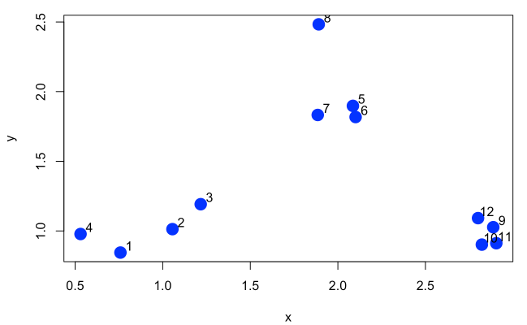

```r
set.seed(1234)
x <- c(0.75, 1.1, 1.25, 0.55, 2.15, 2.17, 1.85, 1.86, 2.87, 2.75, 2.91, 2.71)
y <- c(0.6, 1.0, 1.25, 1.0, 1.9, 1.8, 1.85, 2.5, 1.0, 0.85, 0.86, 1.18)
df_xy <- tibble(x, y)
# Length of dataset
n_xy <- dim(df_xy)[1]
```

Let’s take three clusters for example

```r
Cx = c(1, 1.7, 2.5)
Cy = c(2, 1.0, 1.5)
# Number of clusters define as length of Cx or Cy vectors
n_clust <- length(Cx)
df_cl <- tibble(Cluster = factor(seq(n_clust), ordered = T), Cx, Cy)
```

Next create a dataset with coordinates of observations and coordinates of cluster centers

```r
df_kmeans0 <- bind_cols(df_xy, map_dfr(df_cl, rep, each = length(x) / n_clust))
```

Here’s how all this looks like at the initial stage

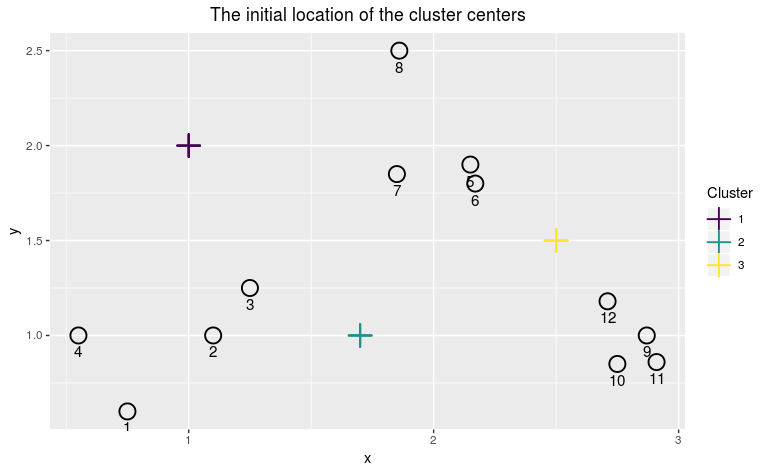

```r
ggplot(df_kmeans0, aes(x, y)) +
  geom_point(shape = 1, size = 5, stroke = 1) +
  geom_text(aes(x, y, label = rownames(df_xy)), vjust = 2.0, size = 4, color = "black") +
  geom_point(aes(Cx, Cy, color = Cluster), shape = 3, size = 5, stroke = 1) +
  labs(title = "The initial location of the cluster centers") +
  theme(plot.title = element_text(hjust = 0.5))
```

Now let’s look what’s happen under the hood of k-means

> Eu_dist<sup>2</sup> = (x<sub>i</sub> - x<sub>c</sub>)<sup>2</sup> + (y<sub>i</sub> - y<sub>c</sub>)<sup>2</sup>

Next, it needs to determine the distance from each point to each cluster. Since we have 12 points and 3 clusters, we get 36 distances. It was the first stumbling-block.

```r
df_dist <- bind_cols(map_dfr(df_xy, rep, n_clust),
                     map_dfr(df_cl, rep, each = n_xy)) %>%
  mutate(Eu_dist = sqrt((.$x - .$Cx)^2 + (.$y - .$Cy)^2))
df_dist
```

| x | y | Cluster | Cx | Cy | Eu_dist |
| --- | --- | --- | --- | --- | --- |
| 0.75 | 0.60 | 1 | 1.0 | 2.0 | 1.4221463 |
| 1.10 | 1.00 | 1 | 1.0 | 2.0 | 1.0049876 |
| 1.25 | 1.25 | 1 | 1.0 | 2.0 | 0.7905694 |
| 0.55 | 1.00 | 1 | 1.0 | 2.0 | 1.0965856 |
| 2.15 | 1.90 | 1 | 1.0 | 2.0 | 1.1543396 |
| 2.17 | 1.80 | 1 | 1.0 | 2.0 | 1.1869709 |
| 1.85 | 1.85 | 1 | 1.0 | 2.0 | 0.8631338 |
| 1.86 | 2.50 | 1 | 1.0 | 2.0 | 0.9947864 |
| 2.87 | 1.00 | 1 | 1.0 | 2.0 | 2.1205895 |
| 2.75 | 0.85 | 1 | 1.0 | 2.0 | 2.0940392 |

[output cut: 26 more lines]

#### **Step.2 Assign each observation to the cluster whose mean has the least squared Euclidean distance**

```r
step2 <- df_dist %>%
  select(-Cx, -Cy) %>%
  spread(Cluster, Eu_dist) %>%
  nest(-x, -y) %>%
  mutate(Eu_dist = map_dbl(.$data, min),
         Cluster = map_dbl(.$data, which.min) %>% factor(., ordered = T)) %>%
  unnest(data) %>%
  arrange(match(x, df_xy$x))
step2
```

| x | y | Eu_dist | Cluster | 1 | 2 | 3 |
| --- | --- | --- | --- | --- | --- | --- |
| 0.75 | 0.60 | 1.0307764 | 2 | 1.4221463 | 1.0307764 | 1.9678669 |
| 1.10 | 1.00 | 0.6000000 | 2 | 1.0049876 | 0.6000000 | 1.4866069 |
| 1.25 | 1.25 | 0.5147815 | 2 | 0.7905694 | 0.5147815 | 1.2747549 |
| 0.55 | 1.00 | 1.0965856 | 1 | 1.0965856 | 1.1500000 | 2.0130822 |
| 2.15 | 1.90 | 0.5315073 | 3 | 1.1543396 | 1.0062306 | 0.5315073 |
| 2.17 | 1.80 | 0.4459821 | 3 | 1.1869709 | 0.9278470 | 0.4459821 |
| 1.85 | 1.85 | 0.7382412 | 3 | 0.8631338 | 0.8631338 | 0.7382412 |
| 1.86 | 2.50 | 0.9947864 | 1 | 0.9947864 | 1.5085092 | 1.1872658 |
| 2.87 | 1.00 | 0.6220129 | 3 | 2.1205895 | 1.1700000 | 0.6220129 |
| 2.75 | 0.85 | 0.6964194 | 3 | 2.0940392 | 1.0606602 | 0.6964194 |

[output cut: 2 more lines]

Columns 1-3 represent all (3 in our case) distances of observation to each cluster. We need to choose the minimum value for each observation. They are gathered in Eu_dist column. So, the columns Eu_dist and Cluster demonstrate which observations to which clusters belong. It was the second and the last stumbling-block.

#### **Step 3. Join cluster’s coordinates to previous dataset**

Now it remains to add the coordinates of cluster centers to our previous data set

```r
step2 %>%
  left_join(df_cl, by = 'Cluster') -> step3
step3
```

| x | y | Eu_dist | Cluster | 1 | 2 | 3 | Cx | Cy |
| --- | --- | --- | --- | --- | --- | --- | --- | --- |
| 0.75 | 0.60 | 1.0307764 | 2 | 1.4221463 | 1.0307764 | 1.9678669 | 1.7 | 1.0 |
| 1.10 | 1.00 | 0.6000000 | 2 | 1.0049876 | 0.6000000 | 1.4866069 | 1.7 | 1.0 |
| 1.25 | 1.25 | 0.5147815 | 2 | 0.7905694 | 0.5147815 | 1.2747549 | 1.7 | 1.0 |
| 0.55 | 1.00 | 1.0965856 | 1 | 1.0965856 | 1.1500000 | 2.0130822 | 1.0 | 2.0 |
| 2.15 | 1.90 | 0.5315073 | 3 | 1.1543396 | 1.0062306 | 0.5315073 | 2.5 | 1.5 |
| 2.17 | 1.80 | 0.4459821 | 3 | 1.1869709 | 0.9278470 | 0.4459821 | 2.5 | 1.5 |
| 1.85 | 1.85 | 0.7382412 | 3 | 0.8631338 | 0.8631338 | 0.7382412 | 2.5 | 1.5 |
| 1.86 | 2.50 | 0.9947864 | 1 | 0.9947864 | 1.5085092 | 1.1872658 | 1.0 | 2.0 |
| 2.87 | 1.00 | 0.6220129 | 3 | 2.1205895 | 1.1700000 | 0.6220129 | 2.5 | 1.5 |
| 2.75 | 0.85 | 0.6964194 | 3 | 2.0940392 | 1.0606602 | 0.6964194 | 2.5 | 1.5 |

[output cut: 2 more lines]

Let’s demonstrate result

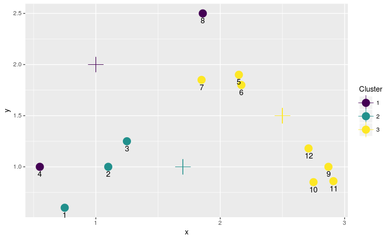

```r
ggplot(step3, aes(x, y, color = Cluster)) +
  geom_point(size = 5) +
  geom_point(aes(x = step3$Cx, y = step3$Cy), shape = 3, size = 7) +
  geom_text(label = rownames(step3), vjust = 1.8, size = 4, color = 'black')
```

#### **Step 4. Recalculation center’s coordinates of new clusters**

```r
step3 %>%
  select(-num_range("", 1:n_clust)) %>%
  group_by(Cluster) %>%
  mutate(Cx2 = mean(x),
         Cy2 = mean(y)) -> step4
step4
```

| x | y | Eu_dist | Cluster | Cx | Cy | Cx2 | Cy2 |
| --- | --- | --- | --- | --- | --- | --- | --- |
| 0.75 | 0.60 | 1.0307764 | 2 | 1.7 | 1.0 | 1.033333 | 0.950000 |
| 1.10 | 1.00 | 0.6000000 | 2 | 1.7 | 1.0 | 1.033333 | 0.950000 |
| 1.25 | 1.25 | 0.5147815 | 2 | 1.7 | 1.0 | 1.033333 | 0.950000 |
| 0.55 | 1.00 | 1.0965856 | 1 | 1.0 | 2.0 | 1.205000 | 1.750000 |
| 2.15 | 1.90 | 0.5315073 | 3 | 2.5 | 1.5 | 2.487143 | 1.348571 |
| 2.17 | 1.80 | 0.4459821 | 3 | 2.5 | 1.5 | 2.487143 | 1.348571 |
| 1.85 | 1.85 | 0.7382412 | 3 | 2.5 | 1.5 | 2.487143 | 1.348571 |
| 1.86 | 2.50 | 0.9947864 | 1 | 1.0 | 2.0 | 1.205000 | 1.750000 |
| 2.87 | 1.00 | 0.6220129 | 3 | 2.5 | 1.5 | 2.487143 | 1.348571 |
| 2.75 | 0.85 | 0.6964194 | 3 | 2.5 | 1.5 | 2.487143 | 1.348571 |

[output cut: 2 more lines]

Let’s look at new clusters (smaller size - are initial values)

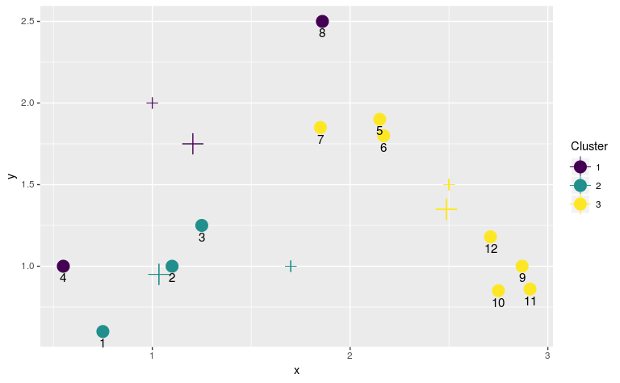

```r
step4 %>%
  ggplot(aes(x, y, color = Cluster)) +
    geom_point(size = 5) +
    geom_point(aes(x = step4$Cx, y = step4$Cy), shape = 3, size = 3) +
    geom_point(aes(x = step4$Cx2, y = step4$Cy2), shape = 3, size = 6) +
    geom_text(aes(label = rownames(step4)), vjust = 1.8, size = 4, color = 'black')
```

Put our dataset with new clusters into “canonical” form

```r
step4 %>%
  select(Cluster, Cx2, Cy2) %>%
  group_by(Cluster) %>%
  unique(.) %>%
  arrange(Cluster) -> new_iteration
new_iteration
```

| Cluster | Cx2 | Cy2 |
| --- | --- | --- |
| 1 | 1.205000 | 1.750000 |
| 2 | 1.033333 | 0.950000 |
| 3 | 2.487143 | 1.348571 |

Next - repeat iteration from step 1 and so on, but for this purpose it needs to have something like recursive function or even two!. I’ve created k_means() function that execute k-means algorithm and wrapper_kmeans() function for calling k_means() in the best way. These function and couple others are contained in helper_functions.R file.  
It must be noted, at this stage I’ve became aware of the principle of k-means, but I wanted to see the result for several iterations and compare one with a regular algorithm - the kmeans() function.  
So, let’s keep on!

### **2. k-means from a bird’s eye view**

Set number of iteration and pass it with observation (df_xy) and cluster (df_cl) tibbles to wraper_kmeans(). It return list of tibbles with observations and clusters from k_means() function from all iterations.

```r
n_iter <- 5 # nubmer of k-means iterations
df_kmeans <- wraper_kmeans(df_xy, df_cl, n_iter)
df_kmeans[[n_iter]]
```

| rowid | x | y | Eu_dist | Cluster | Cx | Cy | Iteration |
| --- | --- | --- | --- | --- | --- | --- | --- |
| 1 | 0.75 | 0.60 | 0.15781250 | 2 | 0.9125 | 0.9625 | Iteration5 |
| 2 | 1.10 | 1.00 | 0.03656250 | 2 | 0.9125 | 0.9625 | Iteration5 |
| 3 | 1.25 | 1.25 | 0.19656250 | 2 | 0.9125 | 0.9625 | Iteration5 |
| 4 | 0.55 | 1.00 | 0.13281250 | 2 | 0.9125 | 0.9625 | Iteration5 |
| 5 | 2.15 | 1.90 | 0.03296250 | 1 | 2.0075 | 2.0125 | Iteration5 |
| 6 | 2.17 | 1.80 | 0.07156250 | 1 | 2.0075 | 2.0125 | Iteration5 |
| 7 | 1.85 | 1.85 | 0.05121250 | 1 | 2.0075 | 2.0125 | Iteration5 |
| 8 | 1.86 | 2.50 | 0.25941250 | 1 | 2.0075 | 2.0125 | Iteration5 |
| 9 | 2.87 | 1.00 | 0.00435625 | 3 | 2.8100 | 0.9725 | Iteration5 |
| 10 | 2.75 | 0.85 | 0.01860625 | 3 | 2.8100 | 0.9725 | Iteration5 |

[output cut: 2 more lines]

Also we can view main results of k_means algorithm for chosen iteration

```r
my_kmeans <- get_kmeans(n_iter, df_kmeans)
glimpse(my_kmeans)
```

```
List of 3
 $ Cluster means                           :Classes ‘tbl_df’, ‘tbl’ and 'data.frame':   3 obs. of  3 variables:
  ..$ Cluster: Ord.factor w/ 3 levels "1"<"2"<"3": 1 2 3
  ..$ Cx     : num [1:3] 2.007 0.913 2.81
  ..$ Cy     : num [1:3] 2.013 0.963 0.972
 $ Clustering vector                       : Ord.factor w/ 3 levels "1"<"2"<"3": 2 2 2 2 1 1 1 1 3 3 ...
 $ Within cluster sum of squares by cluster:Classes ‘tbl_df’, ‘tbl’ and 'data.frame':   3 obs. of  2 variables:
  ..$ Cluster     : Ord.factor w/ 3 levels "1"<"2"<"3": 1 2 3
  ..$ sum(Eu_dist): num [1:3] 0.4151 0.5237 0.0987
```

… and compare it this result of build-in k-means() function

```
K-means clustering with 3 clusters of sizes 4, 4, 4

Cluster means:
       x      y
1 0.9125 0.9625
2 2.0075 2.0125
3 2.8100 0.9725

Clustering vector:
 [1] 1 1 1 1 2 2 2 2 3 3 3 3

Within cluster sum of squares by cluster:
[1] 0.523750 0.415150 0.098675
 (between_SS / total_SS =  90.7 %)

Available components:

[1] "cluster"      "centers"      "totss"        "withinss"     "tot.withinss" "betweenss"    "size"         "iter"         "ifault"
```

And how about visualization? And it is desirable with animation!  
Yes of course! But first make “long” dataframe from the df_kmeans list:

```r
df_long <- map_dfr(df_kmeans, ~ .)
```

Ta da!

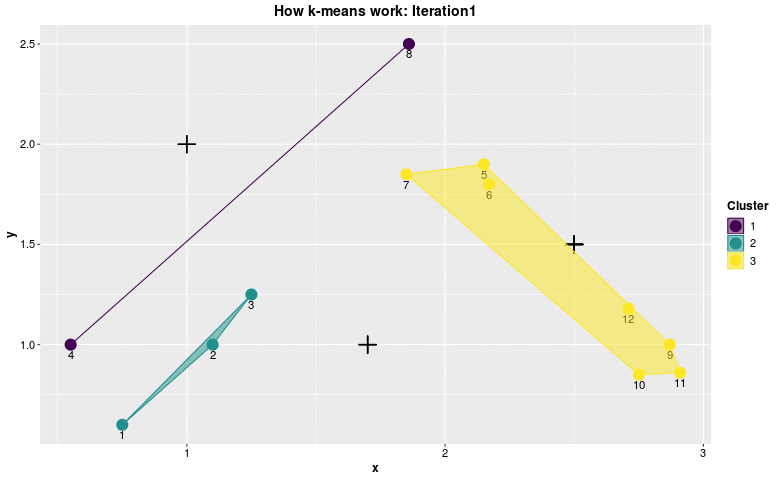

```r
theme_ani <- theme(
          plot.title = element_text(size = 14, face = "bold", hjust = 0.5),
          legend.title = element_text(face = "bold", colour = "black", size = 12),
          legend.text = element_text(size = 11, color = "black"),
          axis.text = element_text(size = 11, colour = "black"),
          axis.title = element_text(size = 12, face = "bold"))
ggplot(df_long, aes(x, y, color = Cluster, frame = Iteration)) +
  geom_point(aes(group = Cluster), size = 5) +
  geom_point(aes(x = Cx, y = Cy), shape = 3, size = 5, color = "black", stroke = 1) +
  geom_path(aes(x = Cx, y = Cy, cumulative = TRUE, group = Cluster),
            color = "black") +
  geom_text(aes(x, y, label = rowid), vjust = 1.8, size = 4, color = 'black') +
  geom_polygon(data = df_polygon(df_kmeans),
               aes(x, y, group = Cluster, fill = Cluster), alpha = .5) +
  labs(title = "How k-means work:") +
  theme_ani -> gg
gganimate(gg)
```

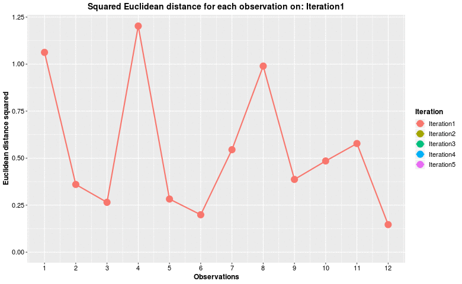

```r
ggplot(df_long, aes(x = rowid, y = Eu_dist, frame = Iteration, cumulative = TRUE)) +
  geom_point(aes(color = Iteration), size = 5) +
  geom_line(aes(color = Iteration), size = 1) +
  scale_x_continuous(breaks = 1:dim(df_xy)[1]) +
  labs(x = "Observations", y = "Euclidean distance squared",
       title = "Squared Euclidean distance for each observation on:") +
  theme_ani -> gg_dist
gganimate(gg_dist)
```

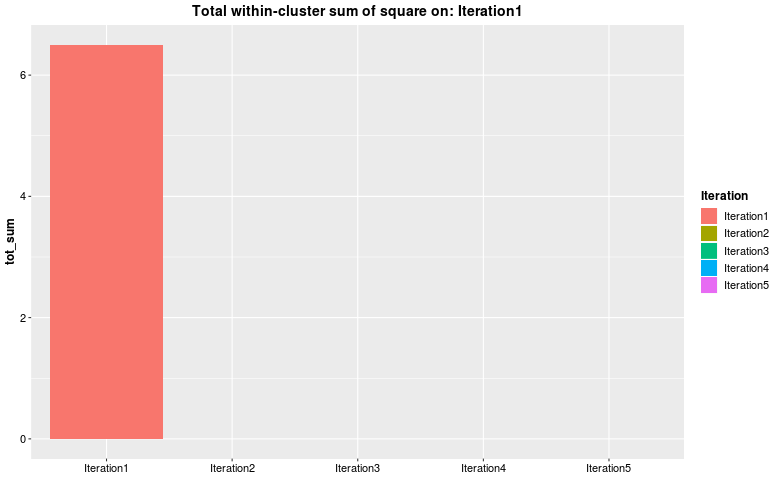

```r
df_long %>%
  group_by(Iteration) %>%
  summarise(tot_sum = sum(Eu_dist)) %>%
  ungroup() %>%
  ggplot(aes(x = Iteration, y = tot_sum, frame = Iteration, cumulative = TRUE)) +
    geom_bar(stat = 'identity', aes(fill = Iteration)) +
    labs(x = NULL, title = "Total within-cluster sum of square on:") +
    theme_ani -> gg_tot_sum
gganimate(gg_tot_sum)
```

#### **Comment#1**

By the end I want to mention some things.  
This is a demonstration example, so the k-means algorithm implemented here may be far from effective. Because of this, I do not recommend using it with large datasets and a large number of iterations (> 10). Of course, you can use your own dataset if you are interested.

#### **Comment#2**

So, what have I achieved by reinventing the wheel:  
1. Understood the [k-means](https://en.wikipedia.org/wiki/K-means_clustering) algorithm, of course)  
2. Improved my skills in [tydiverse](https://www.tidyverse.org/)  
3. Learned to write recursive functions that return two values, one of which is necessary for recursion work, and the other - for external needs (this is what wraper_kmeans() return). This was achieved by the additional wrapper function and the concept of environments.  
4. Learned to make animated charts with gganimate.  
5. Examined chull function from base R  
6. Learned how to [hide comments](https://stackoverflow.com/questions/4823468/comments-in-markdown) in [Rmarkdown](https://rmarkdown.rstudio.com/index.html)

I’d be appriciate for your critical remarks and comments. Well, of course I will be very-very-very happy if this material helps you understand k-means as it helped me! You can find code [here](https://github.com/DmytroRybalko/k-means_explanation)